# Bayesian Hierarchical Models: From Baseball to Elections

Bayesian Statistics

Hierarchical Models

Shrinkage

R

Beta-Binomial, Poisson-Gamma, and Normal-Normal hierarchical models applied to black swans, clinical trials, SAT coaching, baseball batting averages, and election forecasting.

Authors

Nick Polson

Vadim Sokolov

## Introduction

Hierarchical (multilevel) models allow partial pooling of information across groups. Rather than estimating each group separately (no pooling) or ignoring group structure entirely (complete pooling), the hierarchical approach places a prior on the group-level parameters and learns their distribution from the data. The resulting posterior means are Bayesian shrinkage estimators that pull each group’s estimate toward the overall population mean. A classical result due to Stein (1956) and formalized by Efron and Morris (1975) shows that such shrinkage estimators dominate ordinary maximum likelihood in terms of mean squared error when there are three or more parameters to estimate simultaneously.

The examples below move from the simplest conjugate models (Beta-Binomial, Poisson-Gamma, Normal-Normal) through sports and election applications, illustrating in each case how Bayes shrinkage corrects for small-sample over-reaction.

```r
library(LearnBayes)
library(knitr)
library(lattice)
```

## Beta-Binomial: Black Swans

The Beta-Binomial model is the canonical conjugate pair for binary data. With a $\text{Beta}(\alpha, \beta)$ prior on success probability $p$ and $T$ observed successes, the posterior is $\text{Beta}(\alpha + T, \beta)$ (when all trials succeed). Taking a flat $\text{Beta}(1,1)$ prior, the predictive probability of another success after $T$ successes in a row is:

$$p(y_{T+1} = 1 \mid y_1 = \cdots = y_T = 1) = \frac{T+1}{T+2}.$$

This converges to 1, but the complementary probability of ever seeing a failure is:

$$p(y_{T+1} = 0 \mid y_1 = \cdots = y_T = 1) = \frac{1}{T+2}.$$

For any finite $T$ this remains positive: a “black swan” will eventually occur. Hume’s problem of induction is answered probabilistically: past regularity raises confidence but never guarantees the future.

```r
black_swan_prob <- function(T_obs) 1 / (T_obs + 2)

T_vals <- c(1, 5, 10, 50, 100, 500, 1000)
df_bs  <- data.frame(
  T       = T_vals,
  P_success_next = round((T_vals + 1) / (T_vals + 2), 4),
  P_failure_ever = round(1 / (T_vals + 2), 5)
)
kable(df_bs, caption = "Black swan probability after T consecutive successes (Beta(1,1) prior)")
```

Black swan probability after T consecutive successes (Beta(1,1) prior)

| T | P_success_next | P_failure_ever |
| --- | --- | --- |
| 1 | 0.6667 | 0.33333 |
| 5 | 0.8571 | 0.14286 |
| 10 | 0.9167 | 0.08333 |
| 50 | 0.9808 | 0.01923 |
| 100 | 0.9902 | 0.00980 |
| 500 | 0.9980 | 0.00199 |
| 1000 | 0.9990 | 0.00100 |

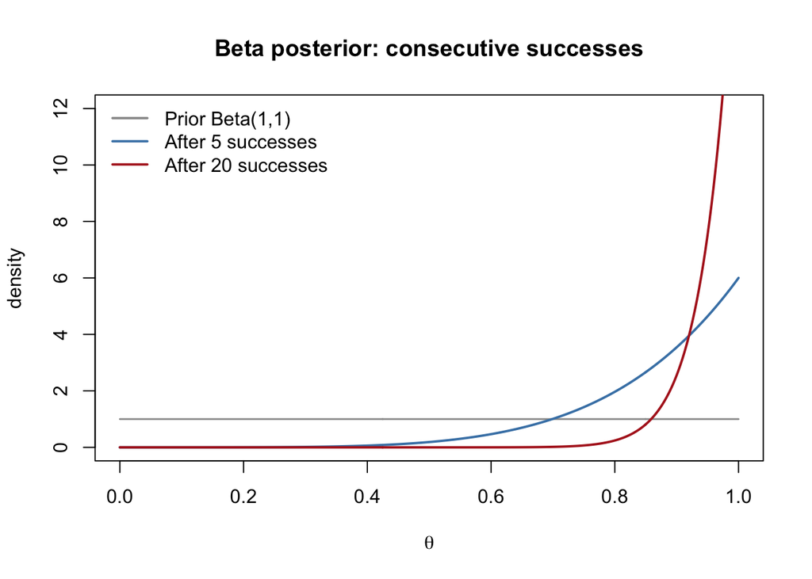

Beta posterior after 0, 5, and 20 consecutive successes

```r
theta <- seq(0, 1, length.out = 300)

plot(theta, dbeta(theta, 1, 1), type = "l", col = "gray60",
     ylim = c(0, 12), ylab = "density", xlab = expression(theta),
     main = "Beta posterior: consecutive successes", lwd = 1.5)
lines(theta, dbeta(theta, 6,  1), col = "steelblue", lwd = 2)
lines(theta, dbeta(theta, 21, 1), col = "firebrick", lwd = 2)
legend("topleft",
       legend = c("Prior Beta(1,1)", "After 5 successes", "After 20 successes"),
       col    = c("gray60", "steelblue", "firebrick"),
       lwd    = 2, bty = "n")
```

## Poisson-Gamma: Clinical Trials

Novick and Grizzle (1965) analyzed four treatments for duodenal ulcers. Doctors assessed patient outcomes as excellent, fair, or death. The death counts are small, making Bayesian analysis especially valuable here.

```r
trials <- data.frame(
  Treatment = c("A", "B", "C", "D"),
  Excellent = c(76, 89, 86, 88),
  Fair      = c(17, 10, 13,  9),
  Death     = c( 7,  1,  1,  3),
  Total     = c(100, 100, 100, 100)
)
kable(trials, caption = "Duodenal ulcer trial: outcome counts by treatment")
```

Duodenal ulcer trial: outcome counts by treatment

| Treatment | Excellent | Fair | Death | Total |
| --- | --- | --- | --- | --- |
| A | 76 | 17 | 7 | 100 |
| B | 89 | 10 | 1 | 100 |
| C | 86 | 13 | 1 | 100 |
| D | 88 | 9 | 3 | 100 |

### Beta-Binomial Comparison

Let $p_i$ be the death rate for treatment $i$. Starting from a flat $\text{Beta}(1,1)$ prior, the posterior for treatment A is $\text{Beta}(8, 94)$ and for B is $\text{Beta}(2, 100)$.

```r
nsim <- 100000
set.seed(42)
pA <- rbeta(nsim, 1 + 7, 1 + 93)
pB <- rbeta(nsim, 1 + 1, 1 + 99)
cat("P(p_A > p_B | data) =", round(mean(pA > pB), 3), "\n")
```

```
P(p_A > p_B | data) = 0.982
```

Treatment A has substantially higher death probability. Classical hypothesis testing fails to reject equality at $\alpha = 0.05$ due to small counts; the Bayesian posterior gives a direct probability statement.

### Poisson-Gamma Sensitivity Analysis

Under the Poisson-Gamma model with prior $\Gamma(m, z)$, the posterior for death rate $\lambda_i$ is $\Gamma(m + d_i, z + 1)$ where $d_i$ is the death count.

```r
pg_prob <- function(d1, d2, m, z, c_val, nsim = 100000) {
  set.seed(42)
  lam1 <- rgamma(nsim, m + d1, z + 1)
  lam2 <- rgamma(nsim, m + d2, z + 1)
  mean(lam1 / lam2 > c_val)
}

priors <- list(c(0, 0), c(100, 2), c(200, 5))
c_vals <- c(1.3, 1.6)
sens   <- expand.grid(c_val = c_vals, prior_idx = seq_along(priors))
sens$prior <- sapply(sens$prior_idx, function(i) paste0("(", priors[[i]][1], ",", priors[[i]][2], ")"))
sens$prob  <- mapply(function(cv, pi) pg_prob(7, 1, priors[[pi]][1], priors[[pi]][2], cv),
                     sens$c_val, sens$prior_idx)
sens$label <- paste0("P(lambda_A/lambda_B > ", sens$c_val, ")")

sens_wide <- reshape(sens[c("label", "prior", "prob")],
                     idvar     = "label",
                     timevar   = "prior",
                     direction = "wide")
names(sens_wide) <- sub("prob\\.", "", names(sens_wide))
kable(sens_wide, digits = 3,
      caption = "Sensitivity analysis: P(lambda_A / lambda_B > c | data) for three priors")
```

Sensitivity analysis: P(lambda_A / lambda_B > c | data) for three priors

| label | (0,0) | (100,2) | (200,5) |
| --- | --- | --- | --- |
| P(lambda_A/lambda_B > 1.3) | 0.981 | 0.072 | 0.01 |
| P(lambda_A/lambda_B > 1.6) | 0.965 | 0.001 | 0.00 |

## Normal-Normal: SAT Coaching

Eight high schools participated in SAT coaching programs. The observed effect $y_j$ and its standard error $\sigma_j$ are available for each school, but sample sizes are small and standard errors large.

```r
schools <- data.frame(
  School = LETTERS[1:8],
  y      = c(28,  8, -3,  7, -1,  1, 18, 12),
  sigma  = c(15, 10, 16, 11,  9, 11, 10, 18)
)
kable(schools, caption = "SAT coaching study: estimated effects and standard errors")
```

SAT coaching study: estimated effects and standard errors

| School | y | sigma |
| --- | --- | --- |
| A | 28 | 15 |
| B | 8 | 10 |
| C | -3 | 16 |
| D | 7 | 11 |
| E | -1 | 9 |
| F | 1 | 11 |
| G | 18 | 10 |
| H | 12 | 18 |

The hierarchical model is:
$$y_j \mid \theta_j \sim N(\theta_j, \sigma_j^2), \qquad
\theta_j \sim N(\mu, \tau^2), \qquad
p(\mu, \tau) \propto 1/\tau.$$

The posterior means $\E{\theta_j \mid y}$ shrink each school’s estimate toward the common mean $\mu$. Schools with larger $\sigma_j$ shrink more.

```r
y_sat     <- schools$y
sigma_sat <- schools$sigma

hier_post <- function(tau, y, sigma) {
  V_j <- 1 / (1/sigma^2 + 1/tau^2)
  mu_hat <- sum(V_j / sigma^2 * y) / sum(V_j / sigma^2)
  theta_j <- V_j * (y / sigma^2 + mu_hat / tau^2)
  list(mu = mu_hat, theta = theta_j, V = V_j)
}

tau_grid <- seq(0.01, 40, length.out = 500)

log_marg <- sapply(tau_grid, function(tau) {
  V_j  <- sigma_sat^2 + tau^2
  mu_h <- sum(y_sat / V_j) / sum(1 / V_j)
  -0.5 * sum(log(V_j)) - 0.5 * sum((y_sat - mu_h)^2 / V_j) - log(tau)
})
log_marg_norm <- log_marg - max(log_marg)
p_tau <- exp(log_marg_norm) / sum(exp(log_marg_norm)) / diff(tau_grid[1:2])

tau_post_mean <- sum(tau_grid * p_tau) * diff(tau_grid[1:2])

hp <- hier_post(tau_post_mean, y_sat, sigma_sat)
```

```r
set.seed(42)
nsim <- 10000
tau_samp <- sample(tau_grid, nsim, replace = TRUE, prob = exp(log_marg_norm))

theta_samp <- t(sapply(tau_samp, function(tau) {
  res <- hier_post(tau, y_sat, sigma_sat)
  rnorm(8, res$theta, sqrt(res$V))
}))

mu_samp <- sapply(tau_samp, function(tau) hier_post(tau, y_sat, sigma_sat)$mu)

quantiles_theta <- apply(theta_samp, 2, quantile, probs = c(0.025, 0.25, 0.5, 0.75, 0.975))
quantiles_mu    <- quantile(mu_samp, probs = c(0.025, 0.25, 0.5, 0.75, 0.975))
quantiles_tau   <- quantile(tau_samp, probs = c(0.025, 0.25, 0.5, 0.75, 0.975))

post_mat <- round(rbind(t(quantiles_theta), mu = quantiles_mu, tau = quantiles_tau), 1)
post_table <- as.data.frame(post_mat)
colnames(post_table) <- c("2.5%", "25%", "50%", "75%", "97.5%")
rownames(post_table) <- c(paste("School", LETTERS[1:8]), "mu", "tau")

kable(post_table, caption = "Posterior quantiles: SAT hierarchical model")
```

Posterior quantiles: SAT hierarchical model

|  | 2.5% | 25% | 50% | 75% | 97.5% |
| --- | --- | --- | --- | --- | --- |
| School A | 6.2 | 7.7 | 7.7 | 7.7 | 12.5 |
| School B | 5.2 | 7.7 | 7.7 | 7.7 | 10.2 |
| School C | 4.3 | 7.7 | 7.7 | 7.7 | 9.9 |
| School D | 5.3 | 7.7 | 7.7 | 7.7 | 10.5 |
| School E | 3.4 | 7.7 | 7.7 | 7.7 | 9.3 |
| School F | 4.2 | 7.7 | 7.7 | 7.7 | 9.8 |
| School G | 6.0 | 7.7 | 7.7 | 7.7 | 12.3 |
| School H | 5.0 | 7.7 | 7.7 | 7.7 | 10.7 |
| mu | 7.7 | 7.7 | 7.7 | 7.7 | 7.9 |
| tau | 0.0 | 0.0 | 0.0 | 0.3 | 5.9 |

## Bayesian Elections: Nate Silver

The Multinomial-Dirichlet model treats state-level polling as a random draw from the true vote shares. For each state $j$, the posterior for Obama’s vote share is a Dirichlet distribution updated by poll percentages.

### 2012 Election

```r
file1       <- "http://www.electoral-vote.com/evp2012/Pres/pres_polls.csv"
election.2012 <- tryCatch(read.csv(file = file1), error = function(e) NULL)
```

```r
library(plyr)

elect2012 <- ddply(election.2012, .(State), subset,   Day == max(Day))
elect2012 <- ddply(elect2012,     .(State), summarise,
                   R.pct = mean(GOP), O.pct = mean(Dem), EV = mean(EV))

kable(elect2012[1:20, ], caption = "2012 polling data (first 20 states)")
```

2012 polling data (first 20 states)

| State | R.pct | O.pct | EV |
| --- | --- | --- | --- |
| Alabama | 61 | 38 | 9 |
| Alaska | 55 | 42 | 3 |
| Arizona | 54 | 44 | 11 |
| Arkansas | 61 | 37 | 6 |
| California | 38 | 59 | 55 |
| Colorado | 47 | 51 | 9 |
| Connecticut | 40 | 58 | 7 |
| D.C. | 7 | 91 | 3 |
| Delaware | 40 | 59 | 3 |
| Florida | 49 | 50 | 29 |
| Georgia | 53 | 45 | 16 |
| Hawaii | 28 | 71 | 4 |
| Idaho | 65 | 33 | 4 |
| Illinois | 41 | 57 | 20 |
| Indiana | 54 | 44 | 11 |
| Iowa | 47 | 52 | 6 |
| Kansas | 60 | 38 | 6 |
| Kentucky | 61 | 38 | 8 |
| Louisiana | 58 | 41 | 8 |
| Maine | 41 | 56 | 4 |

```r
prob.Obama <- function(mydata) {
  p <- rdirichlet(1000,
                  500 * c(mydata$R.pct, mydata$O.pct,
                          100 - mydata$R.pct - mydata$O.pct) / 100 + 1)
  mean(p[, 2] > p[, 1])
}

win.probs        <- ddply(elect2012, .(State), prob.Obama)
win.probs$Romney <- 1 - win.probs$V1
names(win.probs)[2] <- "Obama"
win.probs$EV    <- elect2012$EV
win.probs        <- win.probs[order(win.probs$EV), ]
```

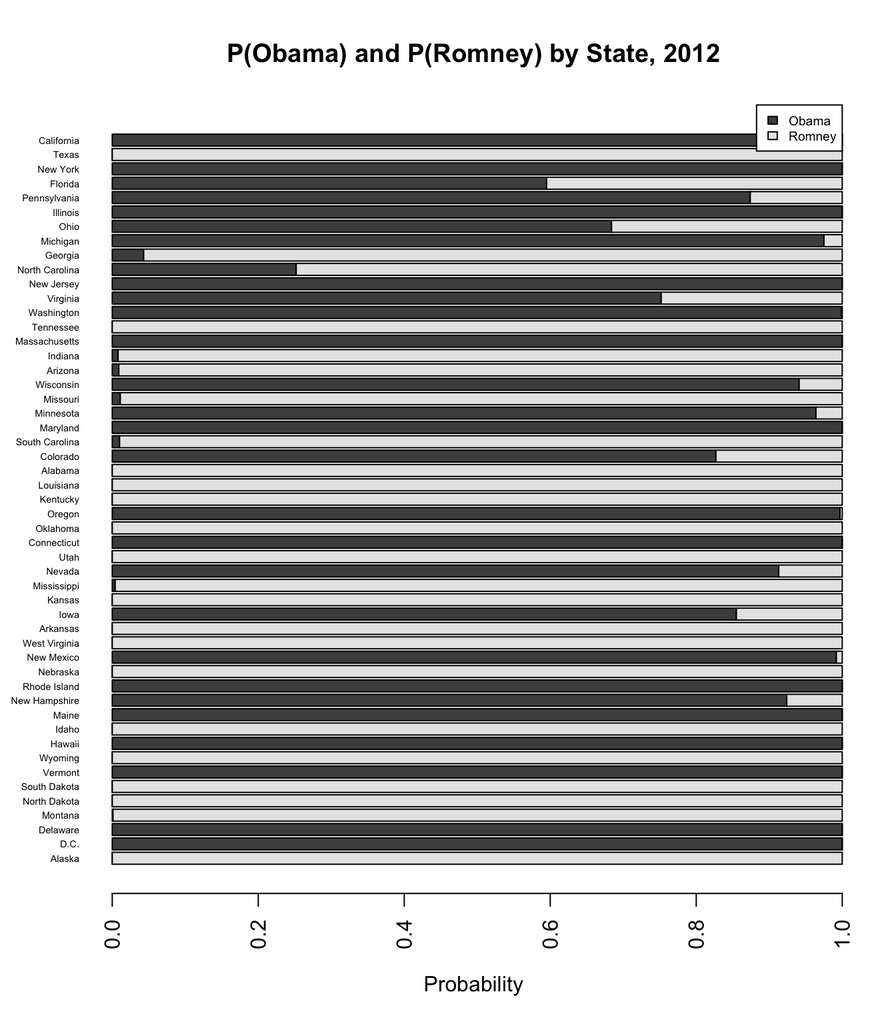

Obama vs Romney win probability by state (2012)

```r
barplot(t(as.matrix(win.probs[, 2:3])),
        legend      = TRUE,
        args.legend = list(x = "topright", cex = 0.6),
        names.arg   = win.probs$State,
        horiz       = TRUE, cex.names = 0.45, las = 2,
        xlab        = "Probability",
        main        = "P(Obama) and P(Romney) by State, 2012")
```

```r
set.seed(42)
sim.election <- function(wp) {
  winner <- rbinom(51, 1, wp$Obama)
  sum(wp$EV * winner)
}

sim.EV  <- replicate(10000, sim.election(win.probs))
oprob   <- mean(sim.EV >= 270)
cat("P(Obama wins | 2012 polls) =", round(oprob, 3), "\n")
```

```
P(Obama wins | 2012 polls) = 0.964
```

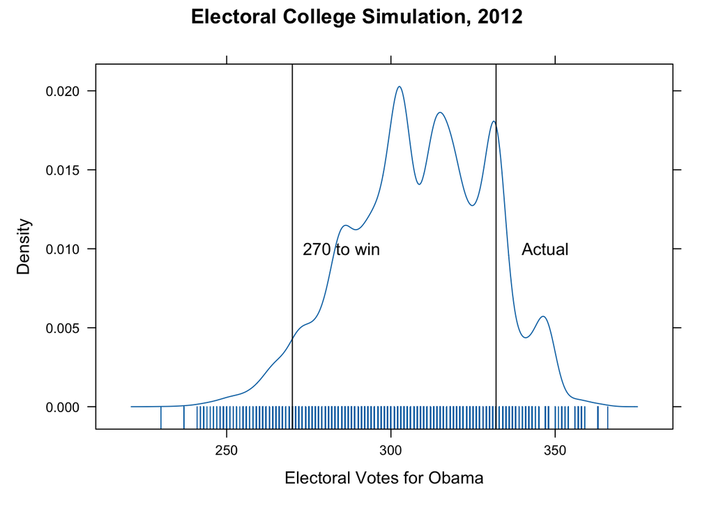

Simulated 2012 electoral vote distribution

```r
densityplot(sim.EV, plot.points = "rug",
            xlab  = "Electoral Votes for Obama",
            panel = function(x, ...) {
              panel.densityplot(x, ...)
              panel.abline(v = 270)
              panel.text(x = 285, y = 0.01, "270 to win")
              panel.abline(v = 332)
              panel.text(x = 347, y = 0.01, "Actual")
            },
            main = "Electoral College Simulation, 2012")
```

### 2008 Election

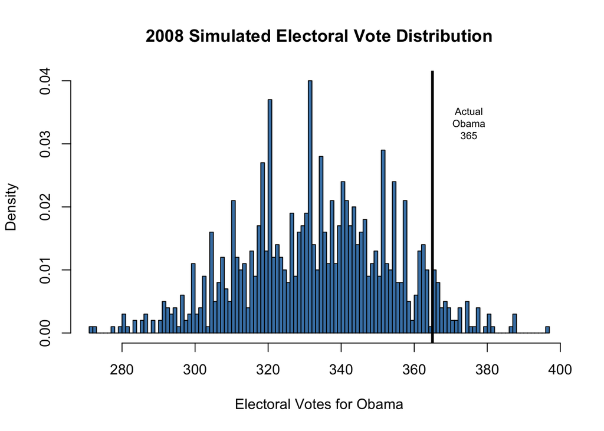

Simulated 2008 electoral vote distribution

```r
data(election.2008)
attach(election.2008)

set.seed(42)
prob.Obama.08 <- function(j) {
  p <- rdirichlet(5000,
                  500 * c(M.pct[j], O.pct[j], 100 - M.pct[j] - O.pct[j]) / 100 + 1)
  mean(p[, 2] > p[, 1])
}

Obama.win.probs <- sapply(1:51, prob.Obama.08)

sim.election.08 <- function() {
  winner <- rbinom(51, 1, Obama.win.probs)
  sum(EV * winner)
}

sim.EV.08 <- replicate(1000, sim.election.08())
hist(sim.EV.08, breaks = min(sim.EV.08):max(sim.EV.08), col = "steelblue",
     prob  = TRUE, xlab = "Electoral Votes for Obama",
     main  = "2008 Simulated Electoral Vote Distribution")
abline(v = 365, lwd = 3)
text(375, par("usr")[4] * 0.8, "Actual\nObama\n365", cex = 0.7)
```

```r
detach(election.2008)
```

## Baseball: Stein’s Paradox

Efron and Morris (1975) used baseball batting averages to illustrate Stein’s paradox: for $k \geq 3$ parameters, the James-Stein estimator has strictly lower mean squared error than the MLE for any true parameter value.

The James-Stein estimator shrinks each player’s observed average toward the grand mean:
$$\hat{\theta}_i^{JS} = c \cdot y_i + (1-c) \cdot \bar{y}, \qquad c = 0.212, \quad \bar{y} = 0.265.$$

```r
bball <- tryCatch(
  read.table(
    paste0("http://www.swarthmore.edu/NatSci/peverso1/Sports%20Data/",
           "JamesSteinData/Efron-Morris%20Baseball/EfronMorrisBB.txt"),
    header = TRUE, stringsAsFactors = FALSE),
  error = function(e) NULL)
```

```r
bball$JS <- bball$BattingAverage * 0.212 + 0.788 * 0.265
kable(bball[c("LastName", "BattingAverage", "RemainingAverage", "JS")],
      digits  = 3,
      caption = "Efron-Morris baseball: first 45 at-bats, season remainder, J-S estimate")
```

Efron-Morris baseball: first 45 at-bats, season remainder, J-S estimate

| LastName | BattingAverage | RemainingAverage | JS |
| --- | --- | --- | --- |
| Clemente | 0.400 | 0.346 | 0.294 |
| Robinson | 0.378 | 0.298 | 0.289 |
| Howard | 0.356 | 0.276 | 0.284 |
| Johnstone | 0.333 | 0.222 | 0.279 |
| Berry | 0.311 | 0.273 | 0.275 |
| Spencer | 0.311 | 0.270 | 0.275 |
| Kessinger | 0.289 | 0.264 | 0.270 |
| Alvarado | 0.267 | 0.210 | 0.265 |
| Santo | 0.244 | 0.269 | 0.261 |
| Swaboda | 0.244 | 0.230 | 0.261 |
| Petrocelli | 0.222 | 0.264 | 0.256 |
| Rodriguez | 0.222 | 0.226 | 0.256 |
| Scott | 0.222 | 0.303 | 0.256 |
| Unser | 0.222 | 0.264 | 0.256 |
| Williams | 0.222 | 0.330 | 0.256 |
| Campaneris | 0.200 | 0.285 | 0.251 |
| Munson | 0.178 | 0.316 | 0.247 |
| Alvis | 0.156 | 0.200 | 0.242 |

```r
mse_mle   <- mean((bball$BattingAverage  - bball$SeasonAverage)^2)
mse_stein <- mean((bball$JS              - bball$SeasonAverage)^2)
cat("MSE (MLE)   =", round(mse_mle, 4), "\n")
```

```
MSE (MLE)   = 0.0033
```

```r
cat("MSE (Stein) =", round(mse_stein, 4), "\n")
```

```
MSE (Stein) = 0.001
```

```r
cat("Improvement factor:", round(mse_mle / mse_stein, 2), "\n")
```

```
Improvement factor: 3.3
```

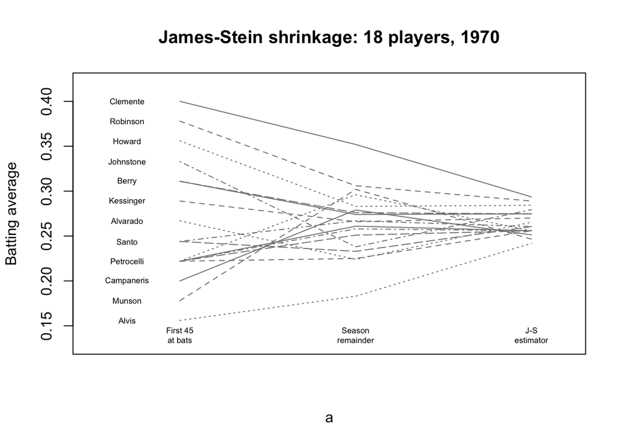

Baseball batting averages: first 45 at-bats, season remainder, J-S estimate

```r
bball$label <- bball$LastName
hide <- c("Scott", "Williams", "Rodriguez", "Unser", "Swaboda", "Spencer")
bball$label[bball$LastName %in% hide] <- ""

a <- matrix(rep(1:3, nrow(bball)), 3, nrow(bball))
b <- matrix(c(bball$BattingAverage, bball$SeasonAverage, bball$JS),
            3, nrow(bball), byrow = TRUE)

matplot(a, b, pch = " ", ylab = "Batting average", xaxt = "n",
        xlim = c(0.5, 3.2), ylim = c(0.13, 0.42),
        main = "James-Stein shrinkage: 18 players, 1970")
matlines(a, b, col = "gray50")
text(rep(0.7, nrow(bball)), bball$BattingAverage, bball$label, cex = 0.55)
text(1, 0.14, "First 45\nat bats",       cex = 0.55)
text(2, 0.14, "Season\nremainder",        cex = 0.55)
text(3, 0.14, "J-S\nestimator",           cex = 0.55)
```

## Baseball Hierarchical: Kenny Lofton

$$\E{p_i \mid y_i, T_i} = \frac{\alpha + y_i}{\alpha + \beta + T_i},$$

where $y_i$ is hits and $T_i$ is at-bats against pitcher $i$.

```r
lofton <- data.frame(
  Pitcher  = c("J.C. Romero", "S. Lewis", "B. Tomko", "T. Hoffman", "K. Tapani",
               "A. Cook", "J. Abbott", "A.J. Burnett", "K. Rogers",
               "A. Harang", "K. Appier", "R. Clemens", "C. Zambrano",
               "N. Ryan", "E. Hanson", "E. Milton", "M. Prior"),
  AtBats   = c( 9,  5, 20,  6, 45,  9, 34, 15, 43,  6, 49, 62,  9, 10, 41, 19,  7),
  Hits     = c( 6,  3, 11,  3, 22,  4, 14,  6, 17,  2, 15, 14,  2,  2,  7,  1,  0),
  ObsAvg   = c(.667,.600,.550,.500,.489,.444,.412,.400,.395,.333,.306,.226,.222,.200,.171,.056,.000)
)

alpha0 <- 0.299 * 50
beta0  <- (1 - 0.299) * 50

lofton$BayesAvg <- round((alpha0 + lofton$Hits) / (alpha0 + beta0 + lofton$AtBats), 3)

kable(lofton, caption = "Kenny Lofton hitting: observed and Bayes estimates (career prior .299)")
```

Kenny Lofton hitting: observed and Bayes estimates (career prior .299)

| Pitcher | AtBats | Hits | ObsAvg | BayesAvg |
| --- | --- | --- | --- | --- |
| J.C. Romero | 9 | 6 | 0.667 | 0.355 |
| S. Lewis | 5 | 3 | 0.600 | 0.326 |
| B. Tomko | 20 | 11 | 0.550 | 0.371 |
| T. Hoffman | 6 | 3 | 0.500 | 0.321 |
| K. Tapani | 45 | 22 | 0.489 | 0.389 |
| A. Cook | 9 | 4 | 0.444 | 0.321 |
| J. Abbott | 34 | 14 | 0.412 | 0.345 |
| A.J. Burnett | 15 | 6 | 0.400 | 0.322 |
| K. Rogers | 43 | 17 | 0.395 | 0.344 |
| A. Harang | 6 | 2 | 0.333 | 0.303 |
| K. Appier | 49 | 15 | 0.306 | 0.303 |
| R. Clemens | 62 | 14 | 0.226 | 0.258 |
| C. Zambrano | 9 | 2 | 0.222 | 0.287 |
| N. Ryan | 10 | 2 | 0.200 | 0.282 |
| E. Hanson | 41 | 7 | 0.171 | 0.241 |
| E. Milton | 19 | 1 | 0.056 | 0.231 |
| M. Prior | 7 | 0 | 0.000 | 0.262 |

```r
cutoff      <- 0.275
bayes_milton <- lofton$BayesAvg[lofton$Pitcher == "E. Milton"]
cat("Bayes estimate vs Milton:", bayes_milton, "\n")
```

```
Bayes estimate vs Milton: 0.231
```

```r
cat("Decision cutoff:", cutoff, "\n")
```

```
Decision cutoff: 0.275
```

```r
cat("Rest Lofton?", ifelse(bayes_milton < cutoff, "Yes (estimate below cutoff)", "No"), "\n")
```

```
Rest Lofton? Yes (estimate below cutoff)
```

The raw average of 0.056 (1 for 19) looks alarming, but the Bayesian estimate shrinks toward Lofton’s career average of .299. The posterior mean against Milton is still below the .275 decision threshold, supporting the manager’s decision to bench Lofton, but by a far smaller margin than the raw data suggest. This is Bayesian shrinkage preventing over-reaction to an extreme small-sample outcome.

### Derek Jeter

```r
jeter <- data.frame(
  Pitcher = c("R. Mendoza", "H. Nomo", "A.J. Burnett", "E. Milton", "D. Cone",
              "R. Lopez", "K. Escobar", "J. Wettland", "T. Wakefield",
              "P. Martinez", "K. Benson", "T. Hudson", "J. Smoltz",
              "F. Garcia", "B. Radke", "D. Kolb", "J. Julio"),
  AtBats  = c(  6,  20,   5,  28,   8,  45,  39,   5,  81,  83,   8,  24,   5,  25,  41,   5,  13),
  Hits    = c(  5,  12,   3,  14,   4,  21,  16,   2,  26,  21,   2,   6,   1,   5,   8,   0,   0),
  ObsAvg  = c(.833,.600,.600,.500,.500,.467,.410,.400,.321,.253,.250,.250,.200,.200,.195,.000,.000)
)

jeter_prior_mean <- 0.316
alpha_j <- jeter_prior_mean * 50
beta_j  <- (1 - jeter_prior_mean) * 50

jeter$EstAvg  <- round((alpha_j + jeter$Hits) / (alpha_j + beta_j + jeter$AtBats), 3)
jeter$CI_low  <- round(qbeta(0.025, alpha_j + jeter$Hits, beta_j + jeter$AtBats - jeter$Hits), 3)
jeter$CI_high <- round(qbeta(0.975, alpha_j + jeter$Hits, beta_j + jeter$AtBats - jeter$Hits), 3)

kable(jeter, caption = "Derek Jeter 2006: hierarchical Bayes estimates (career prior .316)")
```

Derek Jeter 2006: hierarchical Bayes estimates (career prior .316)

| Pitcher | AtBats | Hits | ObsAvg | EstAvg | CI_low | CI_high |
| --- | --- | --- | --- | --- | --- | --- |
| R. Mendoza | 6 | 5 | 0.833 | 0.371 | 0.251 | 0.501 |
| H. Nomo | 20 | 12 | 0.600 | 0.397 | 0.286 | 0.513 |
| A.J. Burnett | 5 | 3 | 0.600 | 0.342 | 0.224 | 0.471 |
| E. Milton | 28 | 14 | 0.500 | 0.382 | 0.278 | 0.492 |
| D. Cone | 8 | 4 | 0.500 | 0.341 | 0.226 | 0.467 |
| R. Lopez | 45 | 21 | 0.467 | 0.387 | 0.292 | 0.487 |
| K. Escobar | 39 | 16 | 0.410 | 0.357 | 0.262 | 0.459 |
| J. Wettland | 5 | 2 | 0.400 | 0.324 | 0.208 | 0.452 |
| T. Wakefield | 81 | 26 | 0.321 | 0.319 | 0.242 | 0.401 |
| P. Martinez | 83 | 21 | 0.253 | 0.277 | 0.204 | 0.355 |
| K. Benson | 8 | 2 | 0.250 | 0.307 | 0.196 | 0.430 |
| T. Hudson | 24 | 6 | 0.250 | 0.295 | 0.197 | 0.403 |
| J. Smoltz | 5 | 1 | 0.200 | 0.305 | 0.192 | 0.432 |
| F. Garcia | 25 | 5 | 0.200 | 0.277 | 0.183 | 0.383 |
| B. Radke | 41 | 8 | 0.195 | 0.262 | 0.177 | 0.356 |
| D. Kolb | 5 | 0 | 0.000 | 0.287 | 0.177 | 0.412 |
| J. Julio | 13 | 0 | 0.000 | 0.251 | 0.153 | 0.364 |

## Chicago Bears 2014-15

The Bears recorded the following point differentials over their first nine games of the 2014-15 season:

```r
bears <- c(-3, 8, 8, -21, -7, 14, -13, -28, -41)
n_bears <- length(bears)
ybar    <- mean(bears)
s       <- sd(bears)
cat("Sample mean:", round(ybar, 3), "\n")
```

```
Sample mean: -9.222
```

```r
cat("Sample SD:", round(s, 3), "\n")
```

```
Sample SD: 18.342
```

The hierarchical model treats the unknown true team strength $\theta$ as:
$$\bar{y} \mid \theta \sim N\!\left(\theta,\, \frac{\sigma^2}{n}\right), \qquad
\theta \sim N(0, \tau^2),$$
with $\tau = 4$ (pre-season prior, roughly a field goal standard deviation) and $n = 9$ games.

```r
tau   <- 4
sig2n <- s^2 / n_bears

shrinkage <- tau^2 / (tau^2 + sig2n)
theta_bayes <- shrinkage * ybar

cat("sigma^2 / n =", round(sig2n, 3), "\n")
```

```
sigma^2 / n = 37.383
```

```r
cat("Shrinkage factor:", round(shrinkage, 3), "\n")
```

```
Shrinkage factor: 0.3
```

```r
cat("Bayes estimate of team strength:", round(theta_bayes, 3), "\n")
```

```
Bayes estimate of team strength: -2.764
```

```r
cat("Current betting line: -3.5\n")
```

```
Current betting line: -3.5
```

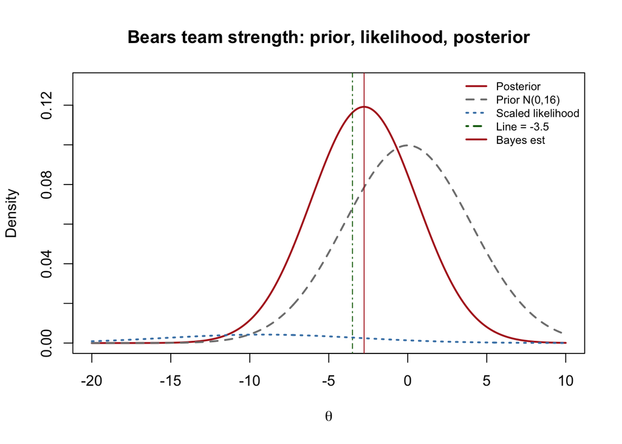

Posterior distribution of Bears team strength

```r
theta_seq <- seq(-20, 10, length.out = 300)
prior_dens <- dnorm(theta_seq, 0, tau)
lik_dens   <- dnorm(theta_seq, ybar, sqrt(sig2n))
post_prec  <- 1/tau^2 + n_bears/s^2
post_mean  <- (ybar * n_bears / s^2) / post_prec
post_sd    <- 1 / sqrt(post_prec)
post_dens  <- dnorm(theta_seq, post_mean, post_sd)

plot(theta_seq, post_dens, type = "l", col = "firebrick", lwd = 2,
     ylim = c(0, max(post_dens, prior_dens, lik_dens) * 1.1),
     xlab = expression(theta), ylab = "Density",
     main = "Bears team strength: prior, likelihood, posterior")
lines(theta_seq, prior_dens, col = "gray50", lwd = 2, lty = 2)
lines(theta_seq, lik_dens / (sqrt(2 * pi * sig2n)), col = "steelblue", lwd = 2, lty = 3)
abline(v = -3.5, col = "darkgreen", lty = 4)
abline(v = theta_bayes, col = "firebrick", lty = 1)
legend("topright",
       legend = c("Posterior", "Prior N(0,16)", "Scaled likelihood", "Line = -3.5", "Bayes est"),
       col    = c("firebrick", "gray50", "steelblue", "darkgreen", "firebrick"),
       lty    = c(1, 2, 3, 4, 1), lwd = 2, bty = "n", cex = 0.75)
```

The probability that the Bears cover the $-3.5$ spread, under the posterior, is:

```r
prob_cover <- pnorm(-3.5, mean = post_mean, sd = post_sd, lower.tail = FALSE)
cat("P(Bears cover -3.5 | data) =", round(prob_cover, 3), "\n")
```

```
P(Bears cover -3.5 | data) = 0.587
```

This is close to 50%, suggesting the line is roughly fair given the hierarchical analysis.